# Overview

# Methods

**1. New Database**  
*Open GeoSysManager. Navigate to Database → New → Save As → [ROI].gsfx*  
**2. Import ITRF2014 CRS (geocentric & geographic); EPSG: 7789, 7912**  
Import two coordinate reference systems (code 7789 and code 7912).  
*Record→ Import Coordinate Reference System → Search → Import*  
These codes stay the same for each campaign

[figure not shown]

**3. Import WGS 84 / UTM projection**  
First it is necessary to determine which UTM zone the data were collected in, using a tool such as What UTM Zone am I in? So for example, the UTM zone for the data collected in 0003PE (Camino Verde, Peru), is 19S (i.e., EPSG:32719).  
*Record → Import Coordinate Reference System → Search → Import*

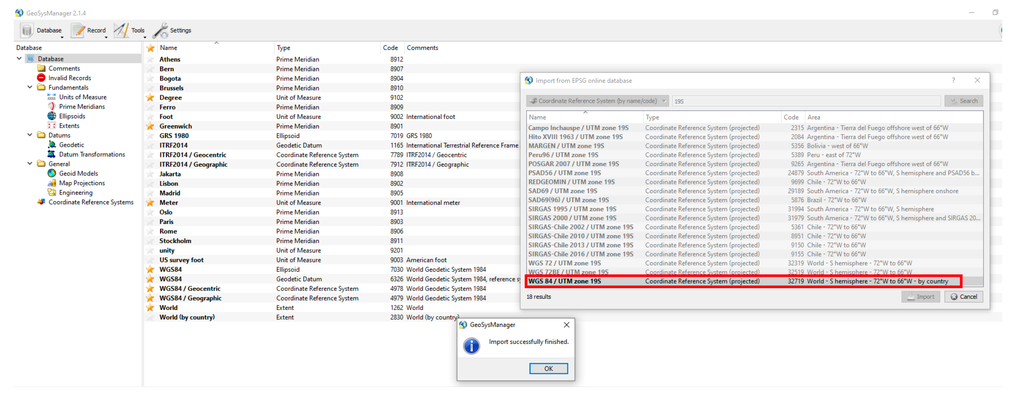

**4. Create ITRF2014 <> WGS84 transformation**  
ITRF2014 and WGS84 are likely to agree at the centimetre level, yielding conventional 0-transformation parameters. Thus, there are no official transformation parameters.  
*Record → New Helmert Transformation → ITRF2014 to WGS84*

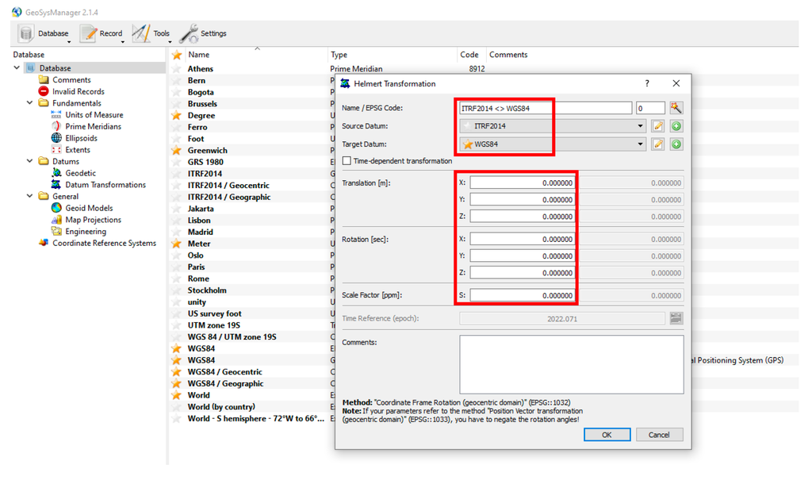

**5. Save Database**  
*Database → Save*